# Time Series Analysis of *Aedes albopictus* Eggs

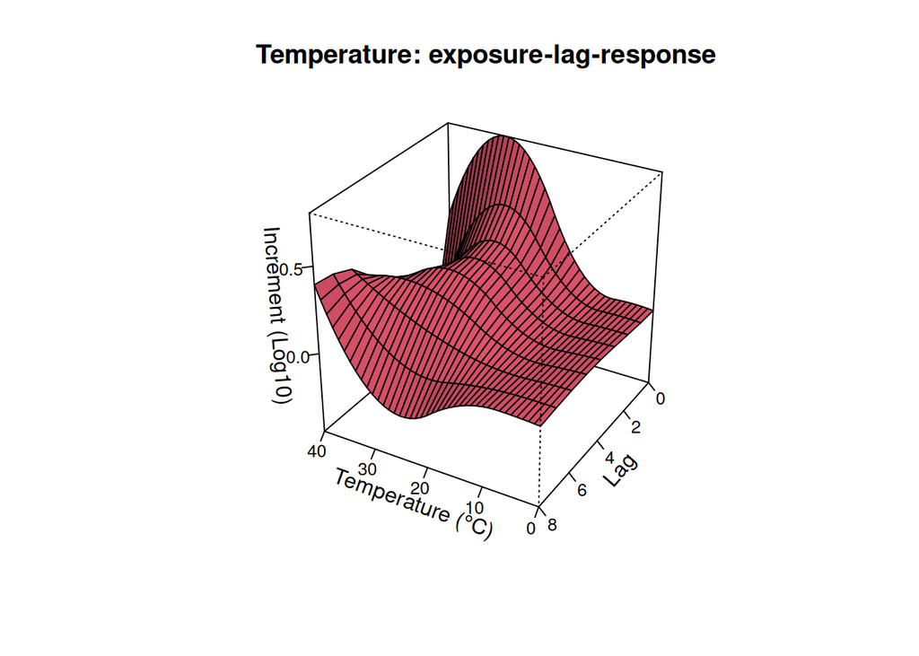

```r
# 3D surface
plot(cptmean, xlab="Temperature (°C)", zlab="Increment (Log10)",
     ltheta=240, lphi=60, cex.axis=0.8,
     main="Temperature: exposure-lag-response", col=2)
```

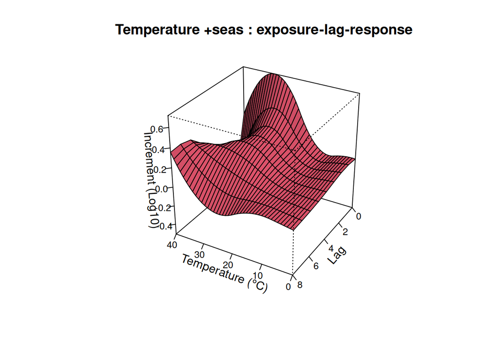

```r
plot(cptmean.seas, xlab="Temperature (°C)", zlab="Increment (Log10)",
     ltheta=240, lphi=60, cex.axis=0.8,
     main="Temperature +seas : exposure-lag-response", col=2)
```

Plot the effect at different lags

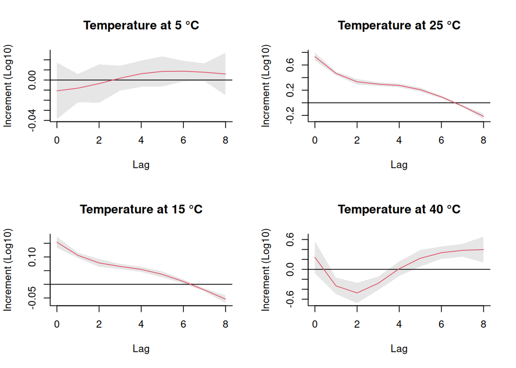

```r
layout(matrix(1:4, ncol=2, nrow = 2))
plot(cptmean, var=5, xlab="Lag", ylab="Increment (Log10)", col=2,
     main="Temperature at 5 °C")

plot(cptmean, var=15, xlab="Lag", ylab="Increment (Log10)", col=2,
     main="Temperature at 15 °C")

plot(cptmean, var=25, xlab="Lag", ylab="Increment (Log10)", col=2,
     main="Temperature at 25 °C")

plot(cptmean, var=40, xlab="Lag", ylab="Increment (Log10)", col=2,
     main="Temperature at 40 °C")
```

```r
layout(1)
```

Plot the effect at different Temperatures

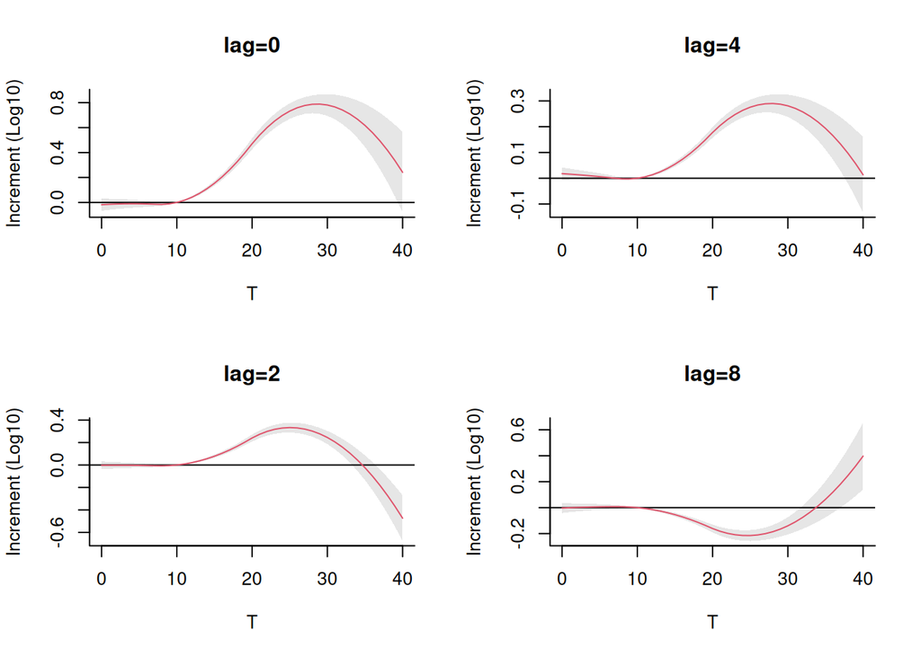

```r
layout(matrix(1:4, ncol=2, nrow = 2))
plot(cptmean, lag=0, xlab="T", ylab="Increment (Log10)", col=2,
     main="lag=0")

plot(cptmean, lag=2, xlab="T", ylab="Increment (Log10)", col=2,
     main="lag=2")

plot(cptmean, lag=4, xlab="T", ylab="Increment (Log10)", col=2,
     main="lag=4")

plot(cptmean, lag=8, xlab="T", ylab="Increment (Log10)", col=2,
     main="lag=8")
```

```r
layout(1)
```

### 4.2 response curves: precipitation

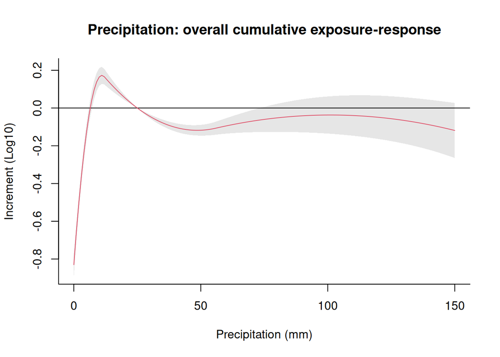

```r
#centering point at 25 mm
myCen <- 25
cppcum <- crosspred(cbPrec, mod_TP, cen=myCen, by=1, at=0:150)
cppcum.seas <- crosspred(cbPrec, mod_TP.seas, cen=myCen, by=1, at=0:150)

# Overall cumulative
plot(cppcum, ptype="overall", xlab="Precipitation (mm)", ylab="Increment (Log10)", col=2,
     main="Precipitation: overall cumulative exposure-response")
```

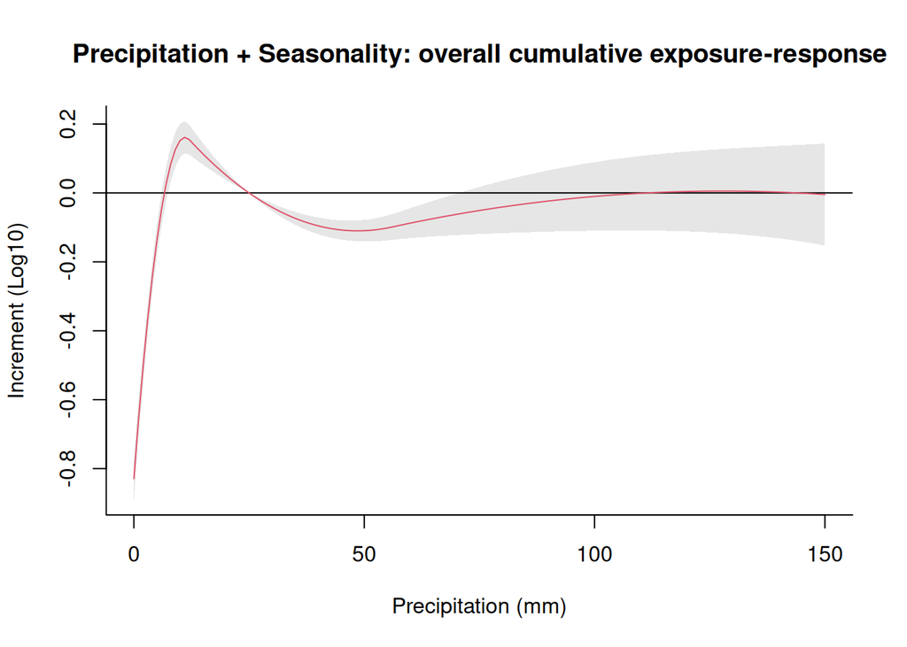

```r
plot(cppcum.seas, ptype="overall", xlab="Precipitation (mm)", ylab="Increment (Log10)", col=2,
     main="Precipitation + Seasonality: overall cumulative exposure-response")
```

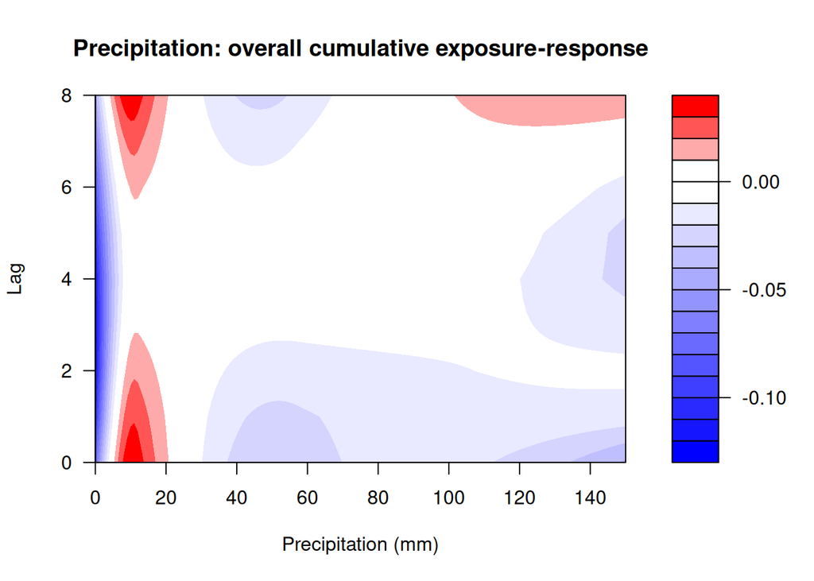

```r
# Contour map 2D
plot(cppcum, "contour", xlab="Precipitation (mm)", ylab="Lag",
     main="Precipitation: overall cumulative exposure-response")
```

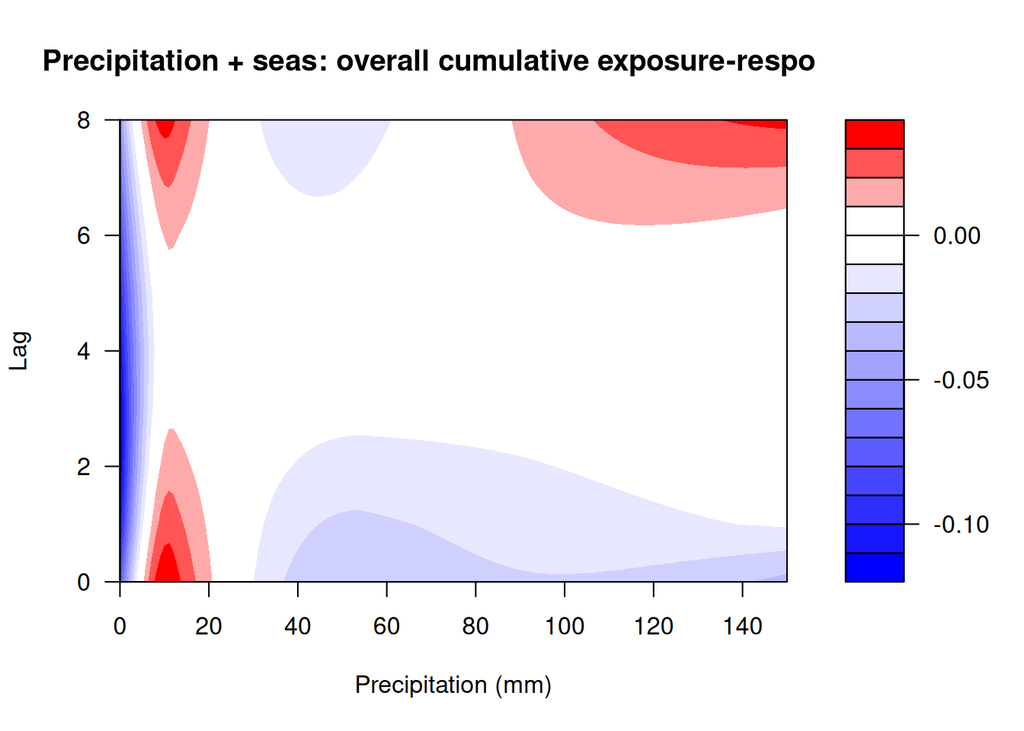

```r
plot(cppcum.seas, "contour", xlab="Precipitation (mm)", ylab="Lag",
     main="Precipitation + seas: overall cumulative exposure-response")
```

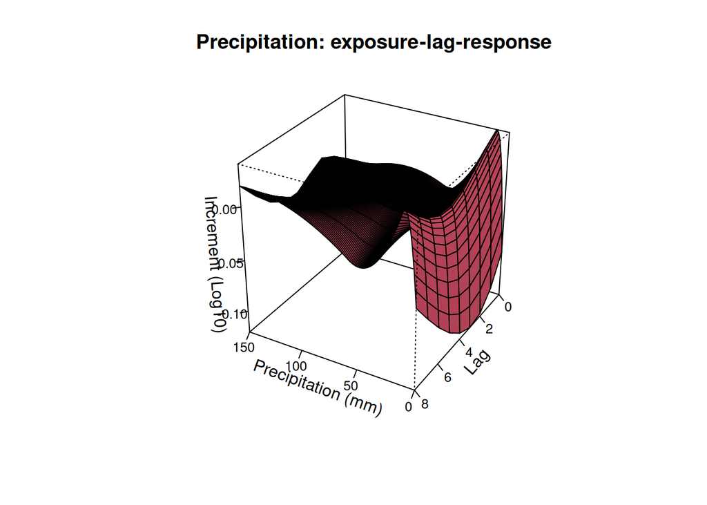

```r
# 3D surface
plot(cppcum, xlab="Precipitation (mm)", zlab="Increment (Log10)",
     ltheta=240, lphi=60, cex.axis=0.8,
     main="Precipitation: exposure-lag-response", col=2)
```

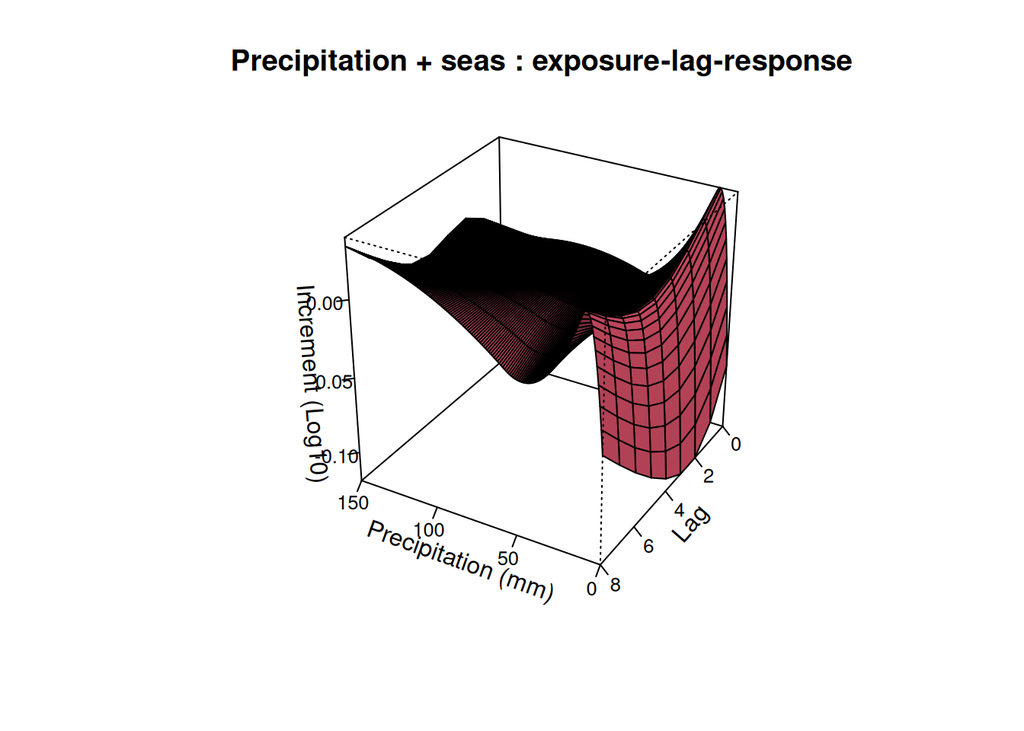

```r
plot(cppcum.seas, xlab="Precipitation (mm)", zlab="Increment (Log10)",
     ltheta=240, lphi=60, cex.axis=0.8,
     main="Precipitation + seas : exposure-lag-response", col=2)
```

Plot the effect at different lags

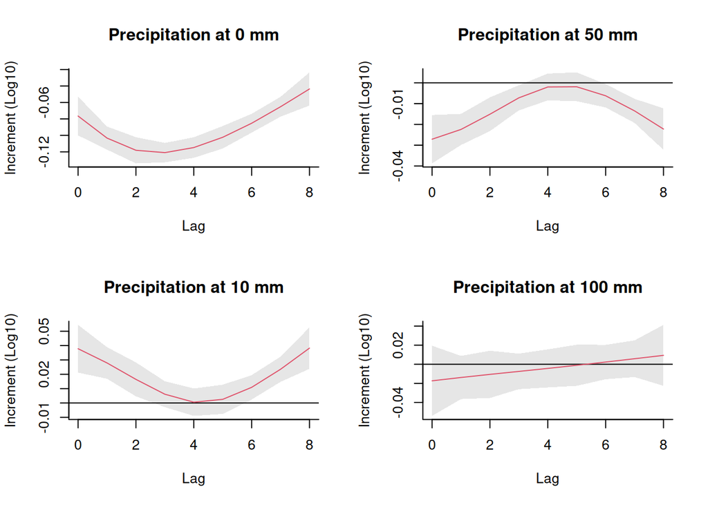

```r
layout(matrix(1:4, ncol=2, nrow = 2))
plot(cppcum, var=0, xlab="Lag", ylab="Increment (Log10)", col=2,
     main="Precipitation at 0 mm")

plot(cppcum, var=10, xlab="Lag", ylab="Increment (Log10)", col=2,
     main="Precipitation at 10 mm")

plot(cppcum, var=50, xlab="Lag", ylab="Increment (Log10)", col=2,
     main="Precipitation at 50 mm")

plot(cppcum, var=100, xlab="Lag", ylab="Increment (Log10)", col=2,
     main="Precipitation at 100 mm")
```

```r
layout(1)
```

Plot the effect at different precipitation values

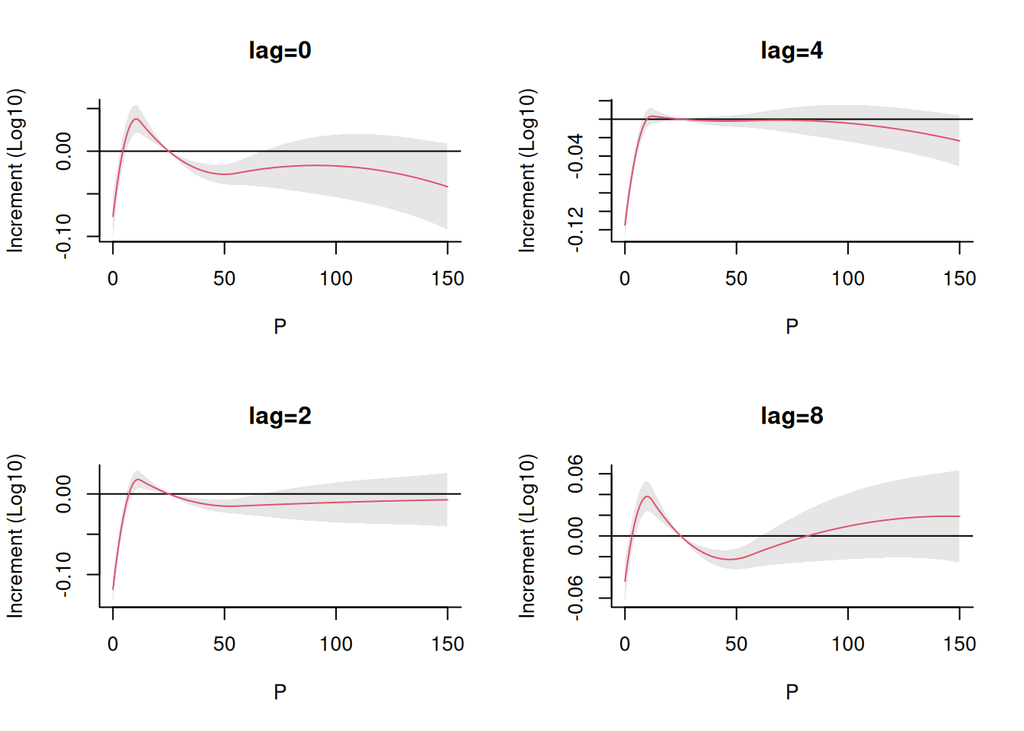

```r
layout(matrix(1:4, ncol=2, nrow = 2))
plot(cppcum, lag=0, xlab="P", ylab="Increment (Log10)", col=2,
     main="lag=0")

plot(cppcum, lag=2, xlab="P", ylab="Increment (Log10)", col=2,
     main="lag=2")

plot(cppcum, lag=4, xlab="P", ylab="Increment (Log10)", col=2,
     main="lag=4")

plot(cppcum, lag=8, xlab="P", ylab="Increment (Log10)", col=2,
     main="lag=8")
```

```r
layout(1)
```

### 4.3 Plot fitted values

Plot values predicted on one random location selected from the calibration dataset.

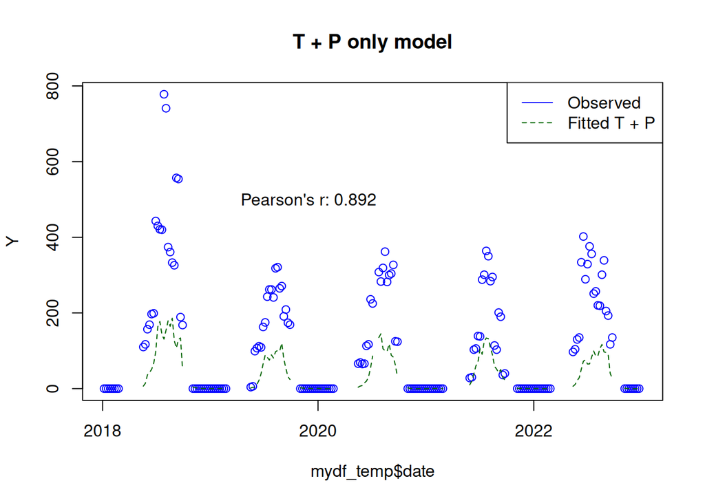

```r
mydf$fitted <- 10^(fitted(mod_TP_pred))-1
mydf$fitted.seas <- 10^(fitted(mod_TP.seas_pred))-1

mydf_temp <- mydf %>%
  filter(ID == ID_subset)

plot(mydf_temp$date, mydf_temp$eggs, type="p" ,col="blue", ylab="Y", main= "T + P only model")
lines(mydf_temp$date, mydf_temp$fitted, col="darkgreen", lty=2)
legend("topright", legend=c("Observed", "Fitted T + P"), col=c("blue", "darkgreen"), lty=c(1,2))
text(x=mydf_temp$date[100],y=500, labels=paste("Pearson's r:", round(cor.test(mydf_temp$eggs, mydf_temp$fitted)$estimate,3)))
```

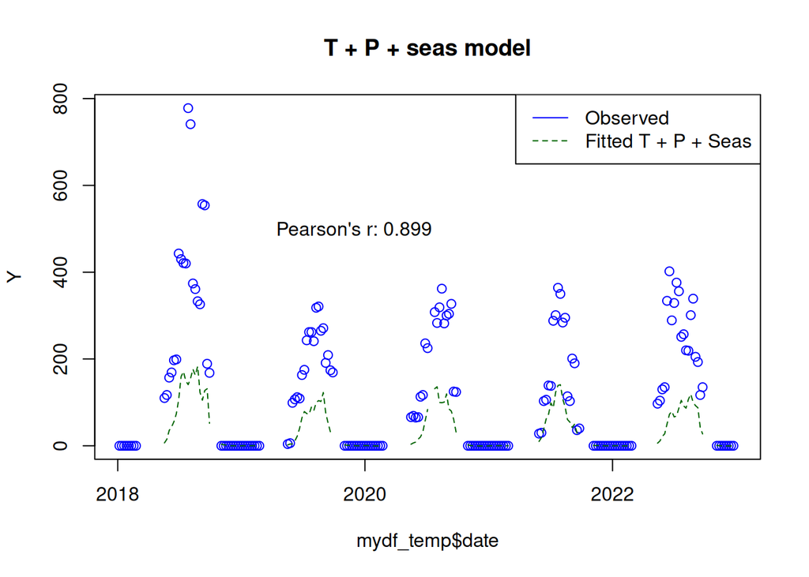

```r
plot(mydf_temp$date, mydf_temp$eggs, type="p" ,col="blue", ylab="Y", main= "T + P + seas model")
lines(mydf_temp$date, mydf_temp$fitted.seas, col="darkgreen", lty=2)
legend("topright", legend=c("Observed", "Fitted T + P + Seas"), col=c("blue", "darkgreen"), lty=c(1,2))
text(x=mydf_temp$date[100],y=500, labels=paste("Pearson's r:", round(cor.test(mydf_temp$eggs, mydf_temp$fitted.seas)$estimate,3)))
```

### 4.4 Validation plot

Plot values predicted on the location that was previously excluded from the model calibration.

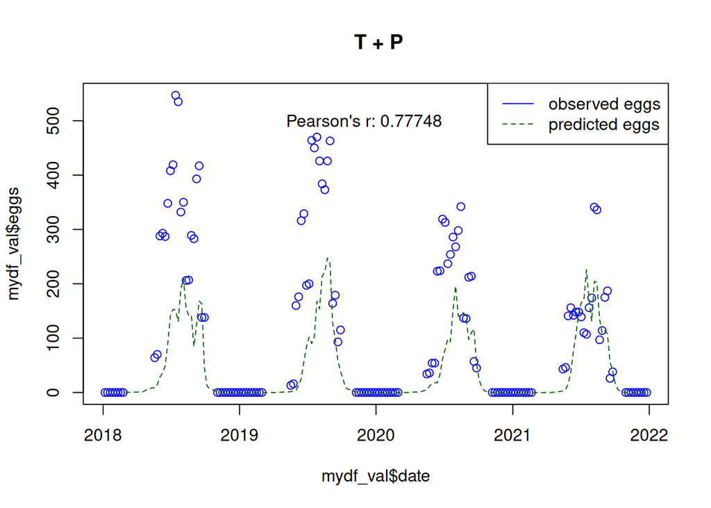

```r
mydf_val <- bio.matrix_sel %>%
  filter(ID == ID_val)

regions <- unique(mydf$Region)

# Build newdf with same shape as original (if needed)
newdf <- data.frame(date = mydf_val$date,
                    cumPrecweek = mydf_val$cumPrecweek,
                    medianTweek = mydf_val$medianTweek)

# Build new crossbasis (T)
cbTemp_val <- crossbasis(newdf$medianTweek, lag=8,
                     argvar=list(fun="bs", degree=2, knots=tknots),
                     arglag=list(knots=c(1,4)),
                     group=newdf$Region)

# Build new crossbasis (P)
cbPrec_val <- crossbasis(newdf$cumPrecweek, lag=8,
                         argvar=list(fun="bs", degree=2, knots=tknots),
                         arglag=list(knots=c(1,4)),
                         group=newdf$Region)

cbTemp_val_df <- as.data.frame(cbTemp_val)
colnames(cbTemp_val_df) <- paste0("cbT", seq_len(ncol(cbTemp_val_df)))
cbPrec_val_df <- as.data.frame(cbPrec_val)
colnames(cbPrec_val_df) <- paste0("cbP", seq_len(ncol(cbPrec_val_df)))

cbTempPrec_val_df <- cbind(cbTemp_val_df, cbPrec_val_df)
newdf_ext <- cbind(newdf, cbTempPrec_val_df)

# Predict
log10eggsPred <- predict(mod_TP_pred, newdata = newdf_ext, type = "response")
mydf_val$eggsPred  = 10^(log10eggsPred)-1

plot(mydf_val$date, mydf_val$eggs, col = "blue", main= " T + P")
lines(newdf$date, mydf_val$eggsPred , col = "darkgreen", lty=2)
legend("topright", legend=c("observed eggs", "predicted eggs"), col=c("blue", "darkgreen"), lty=c(1,2))
text(x=mydf_val$date[100],y=500, labels=paste("Pearson's r:", round(cor.test(mydf_val$eggs, mydf_val$eggsPred)$estimate,5)))
```

Predict also using the model with both Temperature and seasonality.

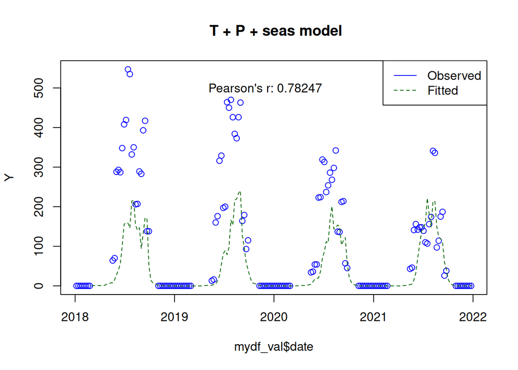

```r
# long interannual temporal trend
btrend <- ns(mydf_val$date, knots=equalknots(mydf_val$date, dftrend-1))
# seasonal intraannual trend
bseas_pred <- ns(mydf_val$month, df=4) #week
bseas_pred_df <- as.data.frame(bseas_pred)
colnames(bseas_pred_df) <- paste0("bt", seq_len(ncol(bseas_pred_df)))
mydf_ext.seas <- cbind(newdf, cbTempPrec_val_df, bseas_pred_df)

# Predict
log10eggsPred <- predict(mod_TP.seas_pred, newdata = mydf_ext.seas, type = "response")
mydf_val$eggsPred_seas  = 10^(log10eggsPred)-1

plot(mydf_val$date, mydf_val$eggs, type="p" ,col="blue", ylab="Y", main= " T + P + seas model")
lines(mydf_val$date, mydf_val$eggsPred_seas , col="darkgreen", lty=2)
legend("topright", legend=c("Observed", "Fitted"), col=c("blue", "darkgreen"), lty=c(1,2))
text(x=mydf_val$date[100],y=500, labels=paste("Pearson's r:", round(cor.test(mydf_val$eggs, mydf_val$eggsPred_seas )$estimate,5)))
```

### 4.5 Risk factors

```r
#Estimation at different T and lags
t.risk.v <- as.character(5*(0:(40/5)))

t.risk.df = data.frame(temp = t.risk.v,
                       allfit = NA,
                       alllow = NA,
                       allhigh = NA)

# can do it both with cptmean and cptmean.seas
for (t.risk in t.risk.v){
  t.risk.df[which(t.risk== t.risk.v),2:4] =
    round(with(cptmean.seas, cbind(allfit, alllow, allhigh)[t.risk,]), 2)
}

t.risk.df
```

```
##   temp allfit alllow allhigh
## 1    0   0.03  -0.01    0.08
## 2    5   0.02  -0.02    0.05
## 3   10   0.00   0.00    0.00
## 4   15   0.43   0.42    0.45
## 5   20   1.38   1.33    1.43
## 6   25   2.15   2.09    2.21
## 7   30   2.23   2.11    2.36
## 8   35   1.63   1.30    1.96
## 9   40   0.34  -0.30    0.98
```

```r
p.risk.v <- as.character(c(0, 10, 20, 40, 60, 90, 120))

p.risk.df = data.frame(prec = p.risk.v,
                       allfit = NA,
                       alllow = NA,
                       allhigh = NA)

# can do it both with cppcum and cppcum.seas
for (p.risk in p.risk.v){
  p.risk.df[which(p.risk== p.risk.v),2:4] =
    round(with(cppcum.seas, cbind(allfit, alllow, allhigh)[p.risk,]), 2)
}

p.risk.df
```

```
##   prec allfit alllow allhigh
## 1    0  -0.83  -0.89   -0.77
## 2   10   0.15   0.10    0.20
## 3   20   0.05   0.04    0.07
## 4   40  -0.10  -0.12   -0.07
## 5   60  -0.09  -0.13   -0.04
## 6   90  -0.02  -0.11    0.07
## 7  120   0.00  -0.11    0.12
```

## 5 Predict egg laying seasonality

To define the start and end of the oviposition season, we adopt the following criteria based on model predictions:

- **Start of the season**: the first week in which predicted egg abundance exceeds 5 egg.
- **End of the season**: the last week in which predicted egg abundance remains above 5 egg.

This threshold-based definition allows for a consistent and interpretable estimate of the egg-laying season across different regions and years, even in the presence of missing observational data.

```r
pred.df <- data.frame(date=as.Date(mydf_ext.seas$date),
                      pred = as.numeric(mydf_val$eggsPred_seas))
pred.df$year <- lubridate::year(pred.df$date)
pred.df$month <- lubridate::month(pred.df$date)
pred.df$week <- lubridate::week(pred.df$date)
pred.df$pred <- ifelse(pred.df$pred <1, 0,pred.df$pred )

seas <- pred.df %>%
  group_by(year) %>%
  filter(pred >5) %>%
  mutate(start = 1*(week==min(week)))%>%
  mutate(end = 1*(week==max(week))) %>%
  filter(start + end > 0) %>%
  ungroup()

#get mean and mode
seas %>%
  filter(start==1) %>%
  reframe(average.WeekStart = mean(week),
          mode_WeekStart = names(which(table(week) == max(table(week)))))
```

```
## # A tibble: 4 × 2
##   average.WeekStart mode_WeekStart
##               <dbl> <chr>
## 1              21.2 19
## 2              21.2 21
## 3              21.2 22
## 4              21.2 23
```

### 5.1 Predict egg laying seasonality in Europe (Extrapolation)

[figure not shown]

```r
env.matrix <- readRDS("envMatrix_2008_2023.RDS") %>%
  rename(medianTweek= tas, cumPrecweek=tp) %>%
  filter(year > 2018) %>%
  as_tibble()

# Build newdf with same shape as original (if needed)
newdf <- data.frame(date = env.matrix$date,
                    cumPrecweek = env.matrix $cumPrecweek,
                    medianTweek = env.matrix $medianTweek)

# Build new crossbasis (T)
cbTemp_val <- crossbasis(newdf$medianTweek, lag=8,
                     argvar=list(fun="bs", degree=2, knots=tknots),
                     arglag=list(knots=c(1,4)),
                     group=newdf$Region)

# Build new crossbasis (P)
cbPrec_val <- crossbasis(newdf$cumPrecweek, lag=8,
                         argvar=list(fun="bs", degree=2, knots=tknots),
                         arglag=list(knots=c(1,4)),
                         group=newdf$Region)

cbTemp_val_df <- as.data.frame(cbTemp_val)
colnames(cbTemp_val_df) <- paste0("cbT", seq_len(ncol(cbTemp_val_df)))
cbPrec_val_df <- as.data.frame(cbPrec_val)
colnames(cbPrec_val_df) <- paste0("cbP", seq_len(ncol(cbPrec_val_df)))

cbTempPrec_val_df <- cbind(cbTemp_val_df, cbPrec_val_df)
newdf_ext <- cbind(newdf, cbTempPrec_val_df)

# Predict ()
log10eggsPred <- predict(mod_TP_pred, newdata = newdf_ext, type = "response")
env.matrix$eggsPred  = 10^(log10eggsPred)-1
env.matrix$eggsPred <- env.matrix$eggsPred*(env.matrix$eggsPred>0)
env.matrix$eggsPred <- round(env.matrix$eggsPred)

# beginning and end of the season defined by the 5 eggs threshold
seas.df <- env.matrix %>%
  group_by(x, y, year) %>%
  filter(eggsPred >5) %>%
  summarise(start = week[which(week==min(week))],
            end = week[which(week==max(week))])%>%
  ungroup()

# get onset, offset and season length
seas.av.df <- seas.df %>%
  group_by(x, y) %>%
  reframe(m.start = mean(start),
          m.end = mean(end),
          s.length =m.end- m.start)

slength <- seas.av.df %>%
  select(x,y,s.length) %>%
  terra::rast(type="xyz")

# Plot season length (months/years)
plot(slength/4, main = "Average season length (months) over 2018-2023")
```

## 6. Mutivariate GLM mod_TP

What if we avoid using the Log-transformed response variable and we go for a GLM?

```r
# Fit mod_Tel to analyse coefficients
mod_TP <- glm(eggs ~  cbTemp + cbPrec,
           #eliminate=stratum, #grouping factor
           data=mydf,
           family=quasipoisson,
           na.action= "na.exclude")

mod_TP.seas <- glm(eggs ~ cbTemp + cbPrec + bseas, # + btrend,
           #eliminate=stratum, #grouping factor
           data=mydf,
           family=quasipoisson,
           na.action= "na.exclude")

AIC(mod_TP, mod_TP.seas)
```

```
##             df AIC
## mod_TP      34  NA
## mod_TP.seas 38  NA
```

```r
# define predictive model
cbTemp_df <- as.data.frame(cbTemp)
cbPrec_df <- as.data.frame(cbPrec)
colnames(cbTemp_df) <- paste0("cbT", seq_len(ncol(cbTemp_df)))
colnames(cbPrec_df) <- paste0("cbP", seq_len(ncol(cbPrec_df)))

cbTempPrec_df <- cbind(cbTemp_df, cbPrec_df)
mydf_ext <- cbind(mydf, cbTempPrec_df)

# Build formula with those columns
form <- as.formula(paste("eggsL10 ~", paste(colnames(cbTempPrec_df), collapse = " + ")))

# Fit mod_Tel to predict on new data
mod_TP_pred <- gnm(form,
                data = mydf_ext,
                family = gaussian(),
                na.action = "na.exclude")

# btrend_df <- as.data.frame(btrend)
# colnames(btrend_df) <- paste0("bt", seq_len(ncol(btrend_df)))
bseas_df <- as.data.frame(bseas)
colnames(bseas_df) <- paste0("bt", seq_len(ncol(bseas_df)))
mydf_ext.seas <- cbind(mydf, cbTempPrec_df, bseas_df) #btrend

# Build formula with those columns
form <- as.formula(paste("eggsL10 ~", paste(colnames( cbind(cbTempPrec_df ,  bseas_df)), collapse = " + "))) # btrend_df,

mod_TP.seas_pred <- gnm(form,
                data = mydf_ext.seas,
                family = gaussian(),
                na.action = "na.exclude")
```

### 6.1 response curves: temperatures

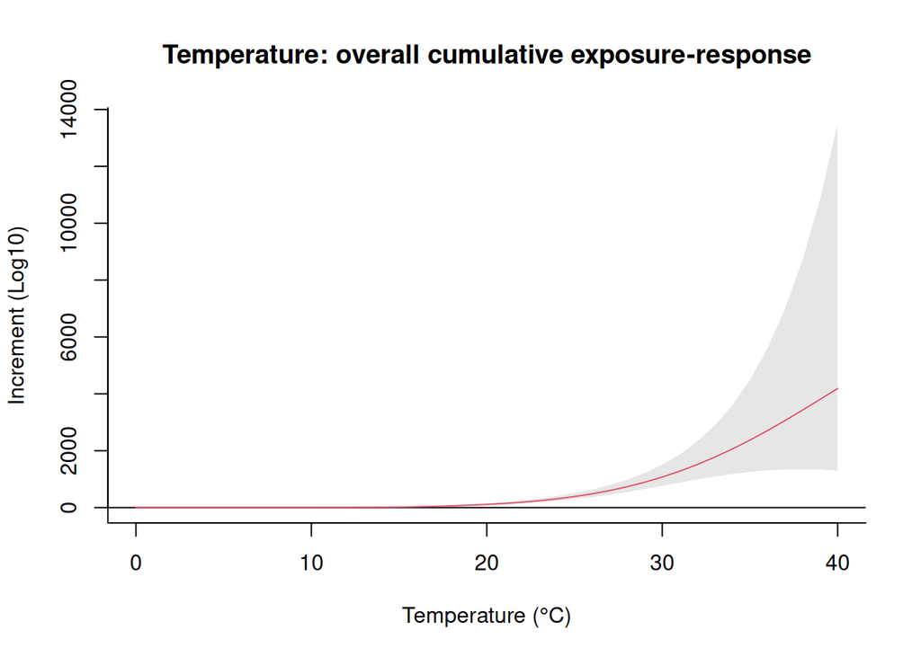

```r
#centering point at 10°C
myCen <- 10
cptmean <- crosspred(cbTemp, mod_TP, cen=myCen, by=1, at=0:40)
cptmean.seas <- crosspred(cbTemp, mod_TP.seas, cen=myCen, by=1, at=0:40)

# Overall cumulative
plot(cptmean, ptype="overall", xlab="Temperature (°C)", ylab="Increment (Log10)", col=2,
     main="Temperature: overall cumulative exposure-response")
```

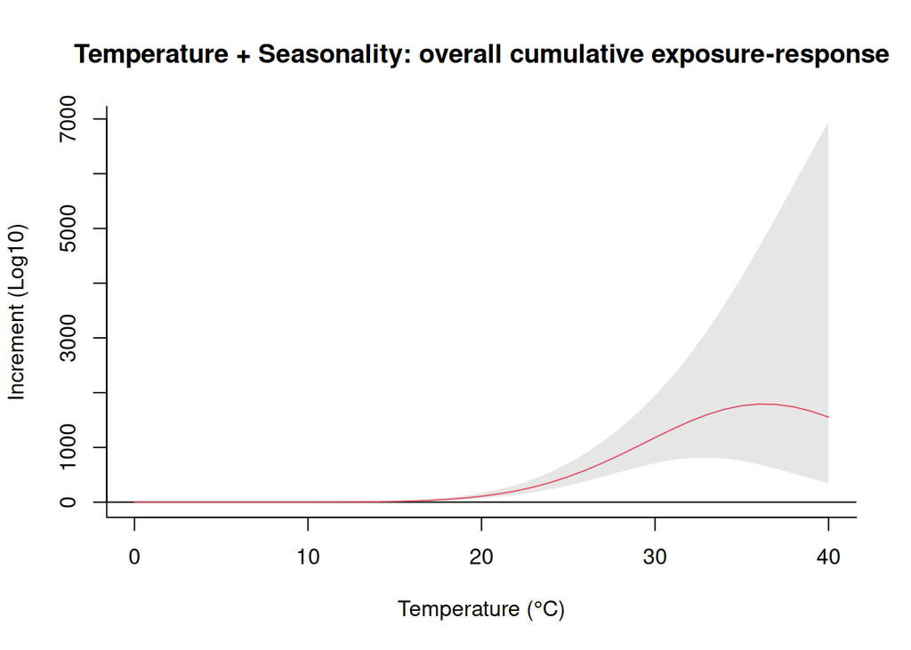

```r
plot(cptmean.seas, ptype="overall", xlab="Temperature (°C)", ylab="Increment (Log10)", col=2,
     main="Temperature + Seasonality: overall cumulative exposure-response")
```

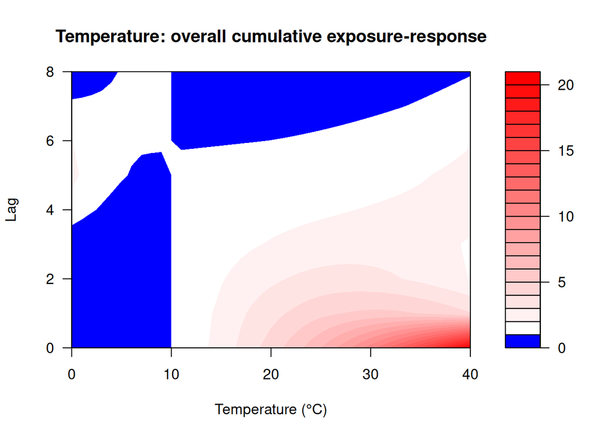

```r
# Contour map 2D
plot(cptmean, "contour", xlab="Temperature (°C)", ylab="Lag",
     main="Temperature: overall cumulative exposure-response")
```

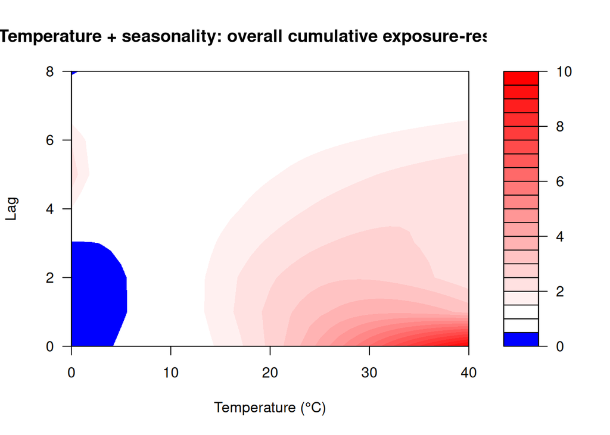

```r
plot(cptmean.seas, "contour", xlab="Temperature (°C)", ylab="Lag",
     main="Temperature + seasonality: overall cumulative exposure-response")
```

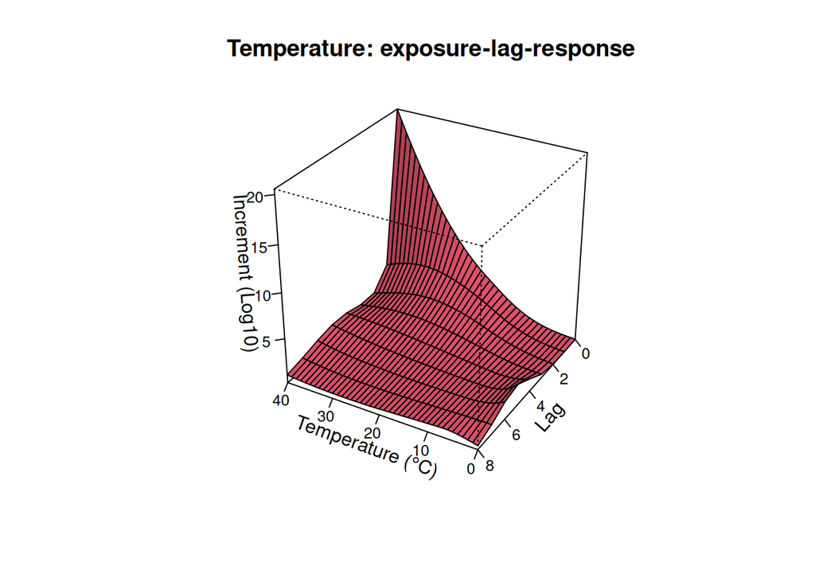

```r
# 3D surface
plot(cptmean, xlab="Temperature (°C)", zlab="Increment (Log10)",
     ltheta=240, lphi=60, cex.axis=0.8,
     main="Temperature: exposure-lag-response", col=2)
```

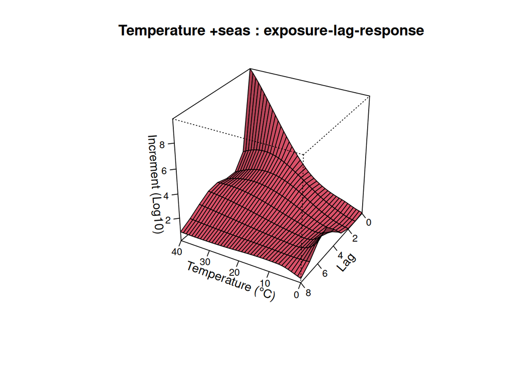

```r
plot(cptmean.seas, xlab="Temperature (°C)", zlab="Increment (Log10)",
     ltheta=240, lphi=60, cex.axis=0.8,
     main="Temperature +seas : exposure-lag-response", col=2)
```

Plot the effect at different lags

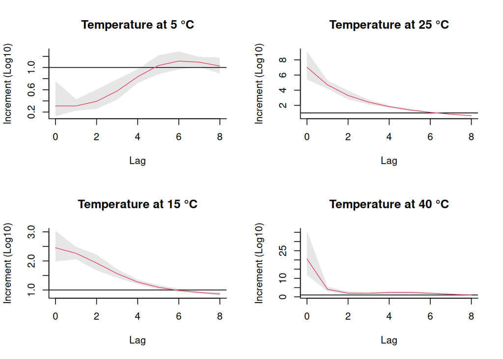

```r
layout(matrix(1:4, ncol=2, nrow = 2))
plot(cptmean, var=5, xlab="Lag", ylab="Increment (Log10)", col=2,
     main="Temperature at 5 °C")

plot(cptmean, var=15, xlab="Lag", ylab="Increment (Log10)", col=2,
     main="Temperature at 15 °C")

plot(cptmean, var=25, xlab="Lag", ylab="Increment (Log10)", col=2,
     main="Temperature at 25 °C")

plot(cptmean, var=40, xlab="Lag", ylab="Increment (Log10)", col=2,
     main="Temperature at 40 °C")
```

```r
layout(1)
```

Plot the effect at different T

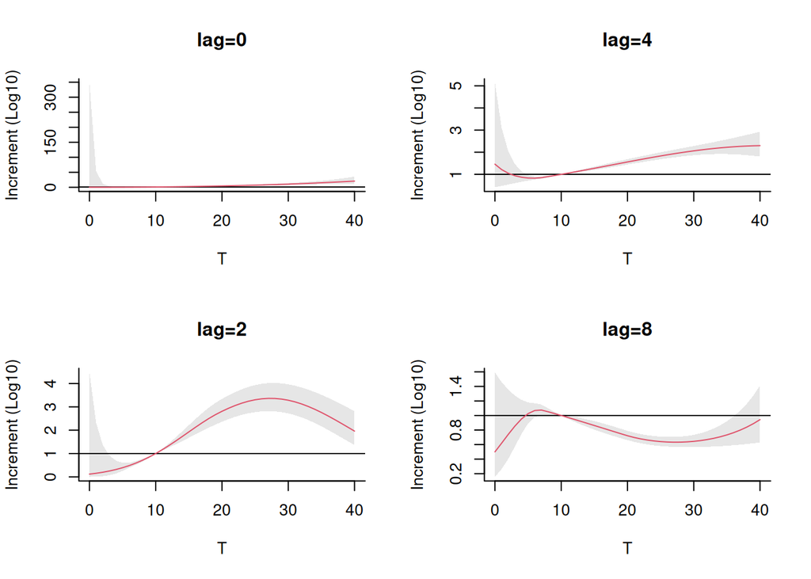

```r
layout(matrix(1:4, ncol=2, nrow = 2))
plot(cptmean, lag=0, xlab="T", ylab="Increment (Log10)", col=2,
     main="lag=0")

plot(cptmean, lag=2, xlab="T", ylab="Increment (Log10)", col=2,
     main="lag=2")

plot(cptmean, lag=4, xlab="T", ylab="Increment (Log10)", col=2,
     main="lag=4")

plot(cptmean, lag=8, xlab="T", ylab="Increment (Log10)", col=2,
     main="lag=8")
```

```r
layout(1)
```

### 6.2 response curves: precipitation

Predict

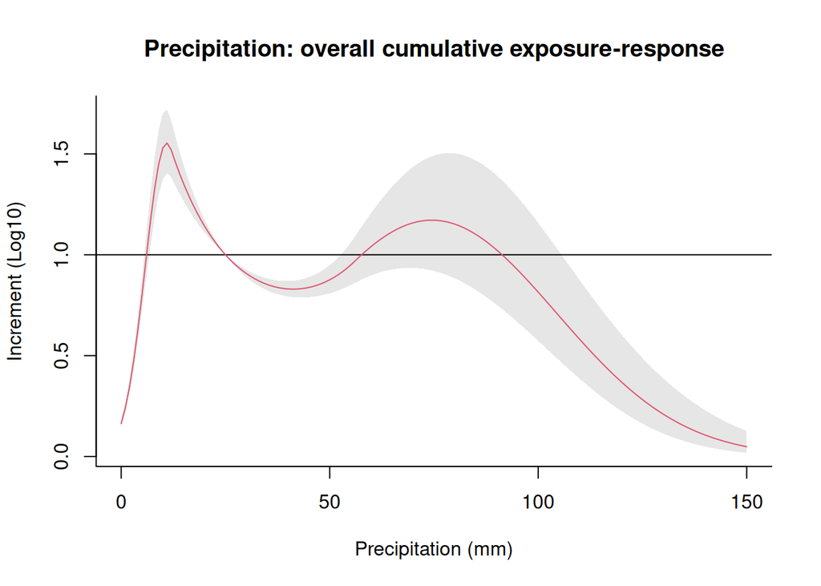

```r
#centering point at 25 mm
myCen <- 25
cptmean <- crosspred(cbPrec, mod_TP, cen=myCen, by=1, at=0:150)
cptmean.seas <- crosspred(cbPrec, mod_TP.seas, cen=myCen, by=1, at=0:150)

# Overall cumulative
plot(cptmean, ptype="overall", xlab="Precipitation (mm)", ylab="Increment (Log10)", col=2,
     main="Precipitation: overall cumulative exposure-response")
```

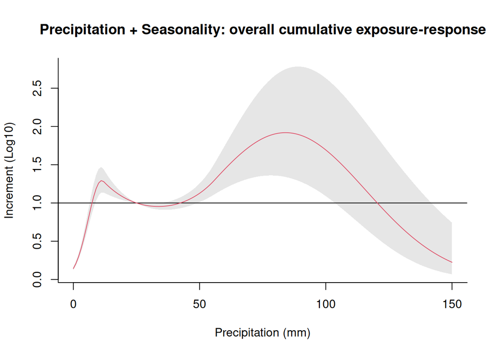

```r
plot(cptmean.seas, ptype="overall", xlab="Precipitation (mm)", ylab="Increment (Log10)", col=2,
     main="Precipitation + Seasonality: overall cumulative exposure-response")
```

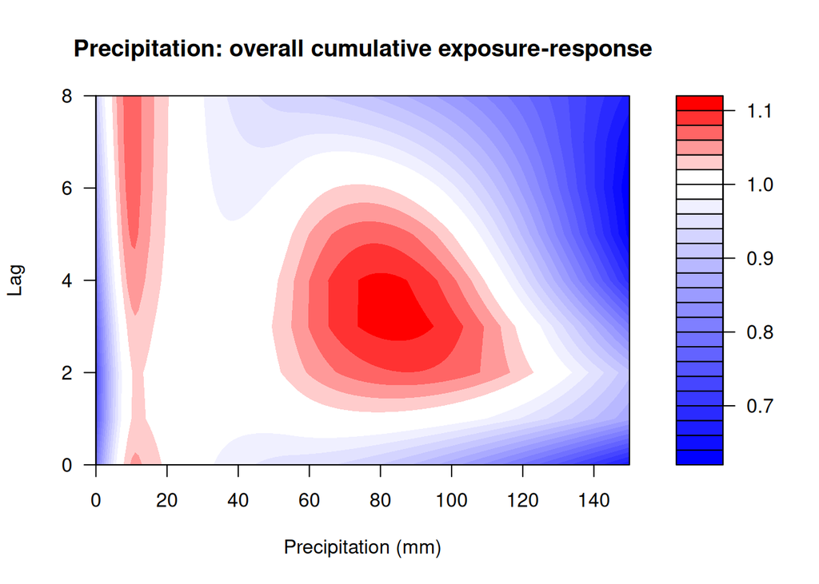

```r
# Contour map 2D
plot(cptmean, "contour", xlab="Precipitation (mm)", ylab="Lag",
     main="Precipitation: overall cumulative exposure-response")
```

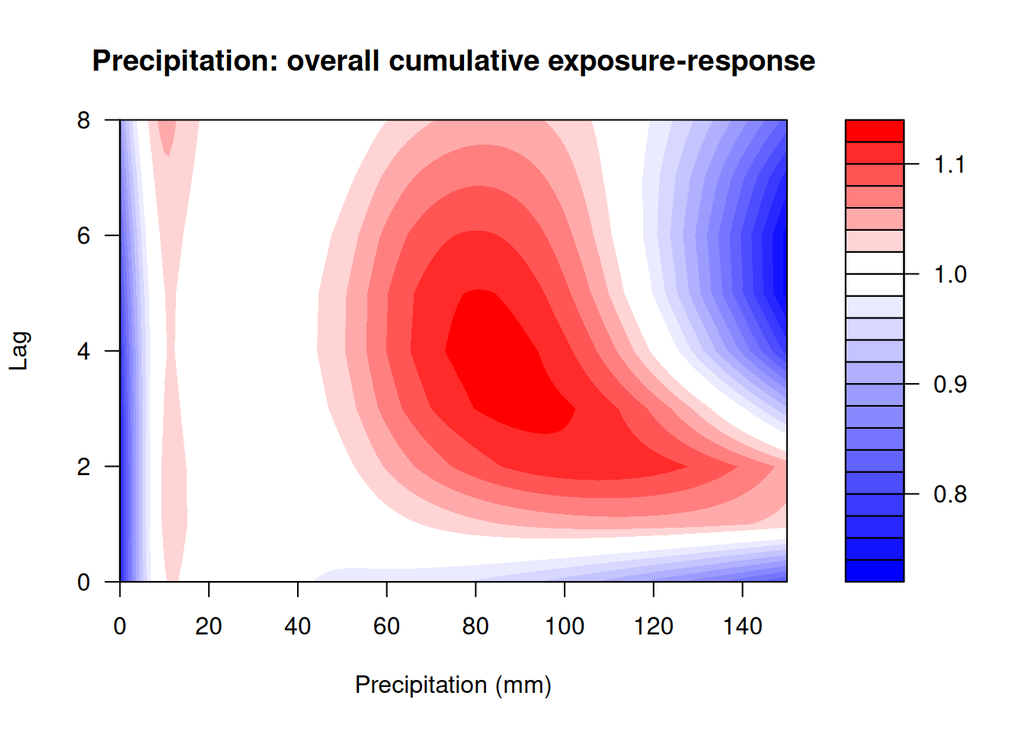

```r
plot(cptmean.seas, "contour", xlab="Precipitation (mm)", ylab="Lag",
     main="Precipitation: overall cumulative exposure-response")
```

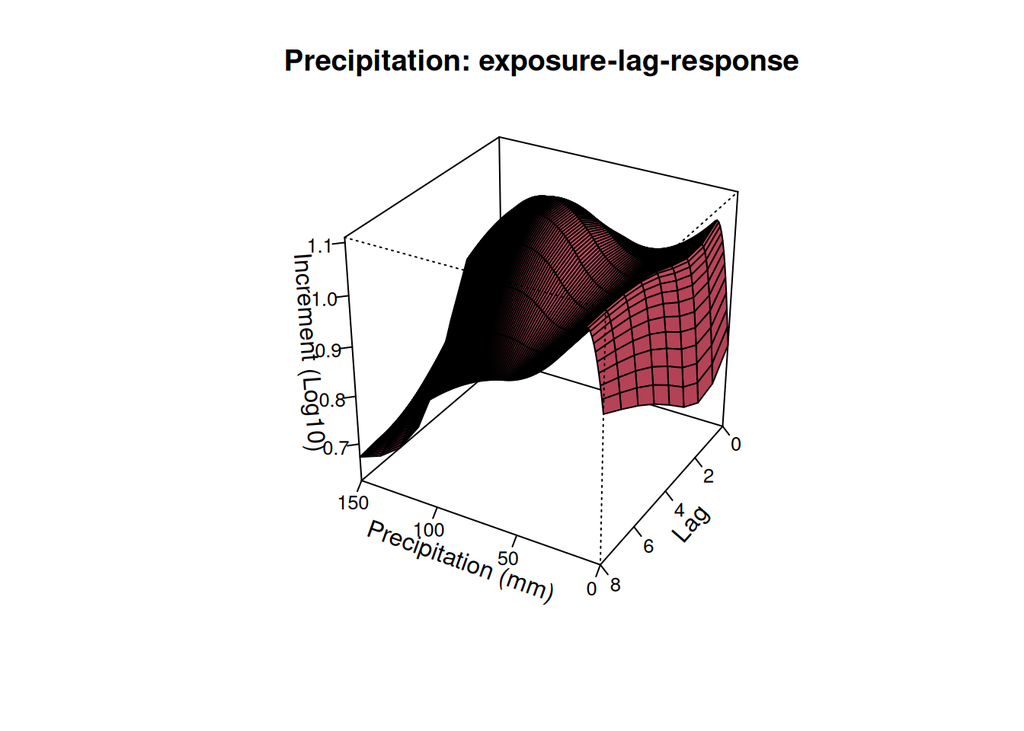

```r
# 3D surface
plot(cptmean, xlab="Precipitation (mm)", zlab="Increment (Log10)",
     ltheta=240, lphi=60, cex.axis=0.8,
     main="Precipitation: exposure-lag-response", col=2)
```

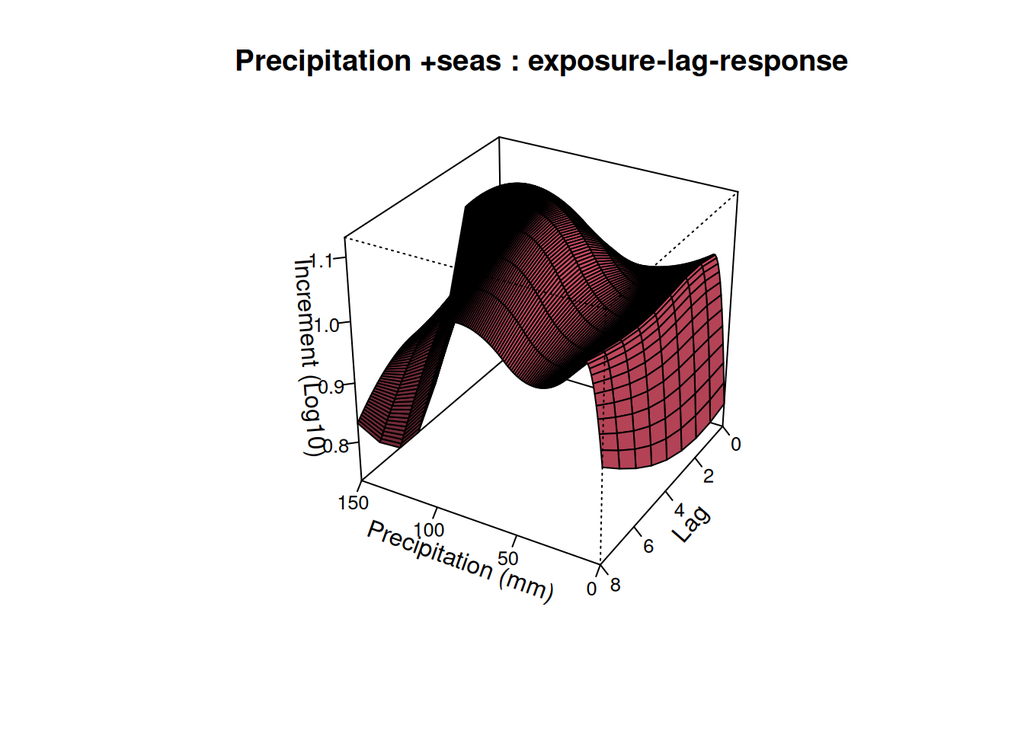

```r
plot(cptmean.seas, xlab="Precipitation (mm)", zlab="Increment (Log10)",
     ltheta=240, lphi=60, cex.axis=0.8,
     main="Precipitation +seas : exposure-lag-response", col=2)
```

Plot the effect at different lags

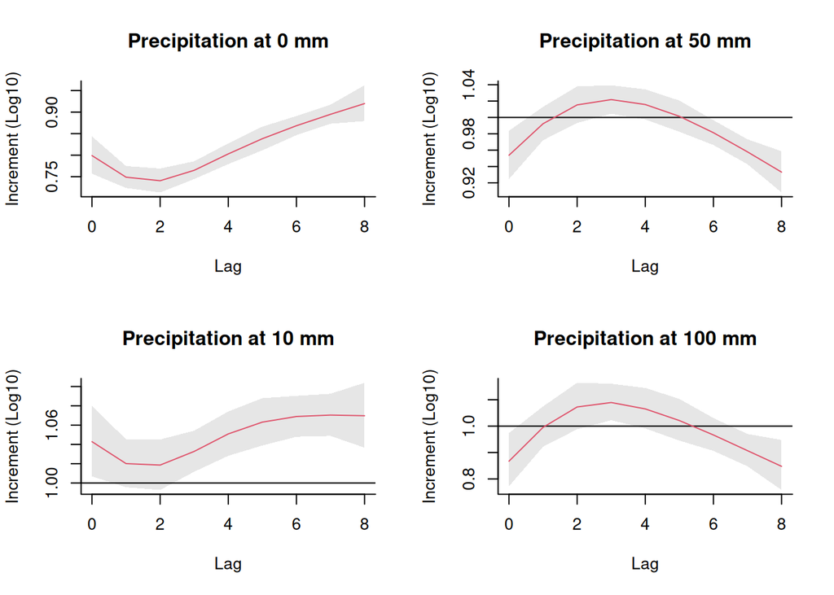

```r
layout(matrix(1:4, ncol=2, nrow = 2))
plot(cptmean, var=0, xlab="Lag", ylab="Increment (Log10)", col=2,
     main="Precipitation at 0 mm")

plot(cptmean, var=10, xlab="Lag", ylab="Increment (Log10)", col=2,
     main="Precipitation at 10 mm")

plot(cptmean, var=50, xlab="Lag", ylab="Increment (Log10)", col=2,
     main="Precipitation at 50 mm")

plot(cptmean, var=100, xlab="Lag", ylab="Increment (Log10)", col=2,
     main="Precipitation at 100 mm")
```

```r
layout(1)
```

Plot the effect at different P

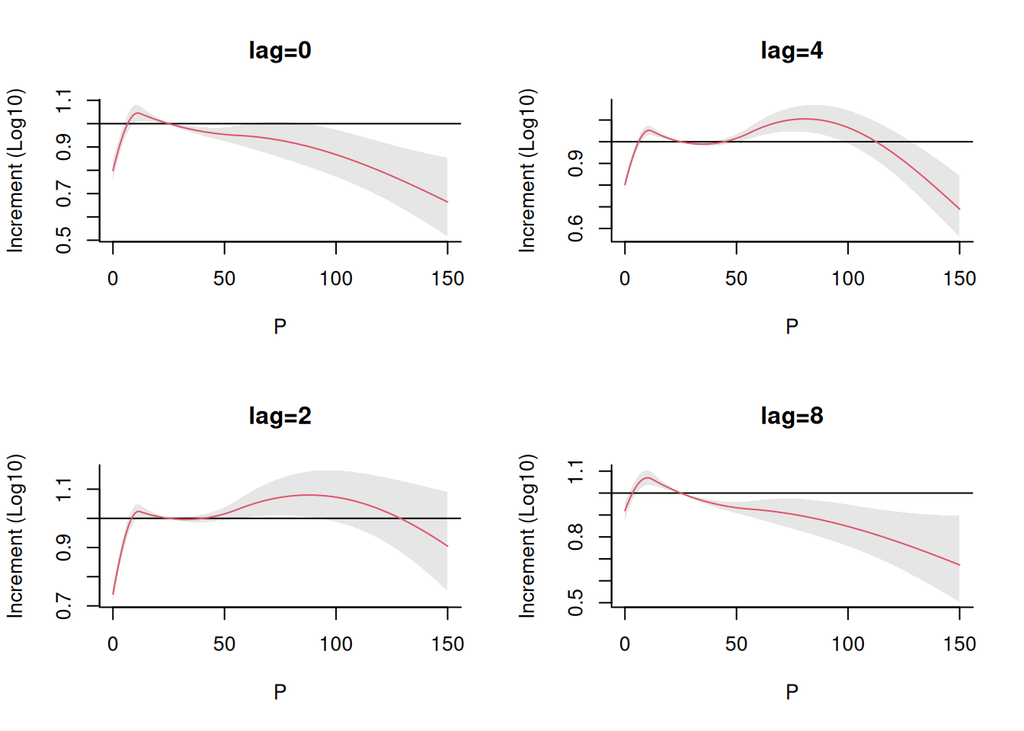

```r
layout(matrix(1:4, ncol=2, nrow = 2))
plot(cptmean, lag=0, xlab="P", ylab="Increment (Log10)", col=2,
     main="lag=0")

plot(cptmean, lag=2, xlab="P", ylab="Increment (Log10)", col=2,
     main="lag=2")

plot(cptmean, lag=4, xlab="P", ylab="Increment (Log10)", col=2,
     main="lag=4")

plot(cptmean, lag=8, xlab="P", ylab="Increment (Log10)", col=2,
     main="lag=8")
```

```r
layout(1)
```

## 7. Discussion points

- **Trasformazione dei dati di abbondanza (uova)**: I dati sulle abbondanze di uova mostrano una distribuzione presumibilmente poissoniana, probabilmente zero-inflated. Abbiamo applicato una trasformazione log10(x + 1) per ridurre l’asimmetria e contenere l’influenza dei valori estremi. *→ Ha senso questa scelta metodologica in questo contesto? Oppure sarebbe preferibile un approccio basato direttamente su modelli zero-inflated o hurdle?*
- **Variabilità tra stazioni e regioni**: Il dataset contiene molte stazioni distribuite su più regioni: questo da un lato arricchisce la base dati, ma introduce anche molto rumore. *→ L’utilizzo del parametro stratum nei modelli consente di tenere conto di questa variabilità spaziale? Può essere considerato equivalente a un “grouping factor” o un effetto casuale (random effect) come nei GLMM?*
- **Trend di lungo periodo e stagionalità**: Abbiamo incluso nel modello due spline naturali per rappresentare il trend di lungo periodo e la stagionalità. *→ Ha senso mantenerli? La scelta di includerli dovrebbe basarsi esclusivamente sull’AIC del modello?*
- **Valutazione dell’effetto cumulato del lag** Appurato che non ha senso calcolare il relative risk per via della formulazione del modello (gaussiano su logaritmo), chi chiedevamo se fosse possibile valutare un effetto cumulato del lag sulla variabile di uscita, analogamente a come si fa per la temperatura *→ Al di là dell’effettiva possibilità, ha senso?*
- Zero inflated models
- check interactions in dlnm in Day2_Session1_Demo_DLM.pdf